# Group Project Stats 112

Alec, Jay, Lynn

5/7/2021

##Setup —

```r
library(tidyverse)
library(nlme)
library(mgcv)
aids = read.csv("aids.csv")

glimpse(aids)
```

```
## Rows: 5,036
## Columns: 6
## $ id        <int> 1, 1, 1, 1, 1, 1, 2, 2, 2, 2, 2, 2, 3, 4, 4, 4, 4, 5, 5, 5,…
## $ treatment <int> 2, 2, 2, 2, 2, 2, 4, 4, 4, 4, 4, 4, 1, 3, 3, 3, 3, 1, 1, 1,…
## $ age       <dbl> 36.4271, 36.4271, 36.4271, 36.4271, 36.4271, 36.4271, 47.84…
## $ gender    <chr> "male", "male", "male", "male", "male", "male", "male", "ma…
## $ week      <dbl> 0.0000, 7.5714, 15.5714, 23.5714, 32.5714, 40.0000, 0.0000,…
## $ log_cd4   <dbl> 3.135494, 3.044522, 2.772589, 2.833213, 3.218876, 3.044522,…
```

##Exploratory Data Analysis —

```r
subjects = unique(aids$id)
subjects = max(subjects)
```

##Univariate summaries

```r
summary(aids)
```

```
##        id           treatment          age           gender
##  Min.   :   1.0   Min.   :1.000   Min.   :14.90   Length:5036
##  1st Qu.: 318.8   1st Qu.:2.000   1st Qu.:31.76   Class :character
##  Median : 640.5   Median :3.000   Median :36.85   Mode  :character
##  Mean   : 654.5   Mean   :2.516   Mean   :37.73
##  3rd Qu.: 988.0   3rd Qu.:4.000   3rd Qu.:42.54
##  Max.   :1313.0   Max.   :4.000   Max.   :74.19
##       week          log_cd4
##  Min.   : 0.00   Min.   :0.000
##  1st Qu.: 0.00   1st Qu.:2.303
##  Median :15.86   Median :2.944
##  Mean   :15.46   Mean   :2.872
##  3rd Qu.:25.00   3rd Qu.:3.570
##  Max.   :40.00   Max.   :6.297
```

```r
aids %>%
  summarize(mean_log_cd4 = mean(log_cd4, na.rm = TRUE),
            stdev_log_cd4 = sd(log_cd4, na.rm = TRUE))
```

```
##   mean_log_cd4 stdev_log_cd4
## 1     2.871802      1.078326
```

```r
aids %>%
  group_by(treatment) %>%
  summarize(mean_log_cd4 = mean(log_cd4, na.rm = TRUE),
            stdev_log_cd4 = sd(log_cd4, na.rm = TRUE))
```

```
## # A tibble: 4 x 3
##   treatment mean_log_cd4 stdev_log_cd4
## *     <int>        <dbl>         <dbl>
## 1         1         2.75         0.947
## 2         2         2.80         1.06
## 3         3         2.91         1.12
## 4         4         3.02         1.15
```

We can see that for this longitudinal study, the log_cd4 values range from 0 to 6.29, with a median of 2.9 and a mean of 2.87. The 3rd quantile is around 3.57, but the maximum is 6.297, which may indicate that we have potential outlier. When we look at the overall mean and standard deviation of log(cd4), the mean is around 2.87 and the standard deviation is around 1.07. We can see that the maximum log_cd4 value 6.29 is more than 2 standard deviations away from the overall mean, supporting our estimate that that value could be an outlier in the dataset. We can also see in the upcoming boxplots that there are some outliers. When we look at the mean and standard deviations of log_cd4 for each treatment group, we can see that as the treatment code increases, the mean and standard deviation of log_cd4 also increases.

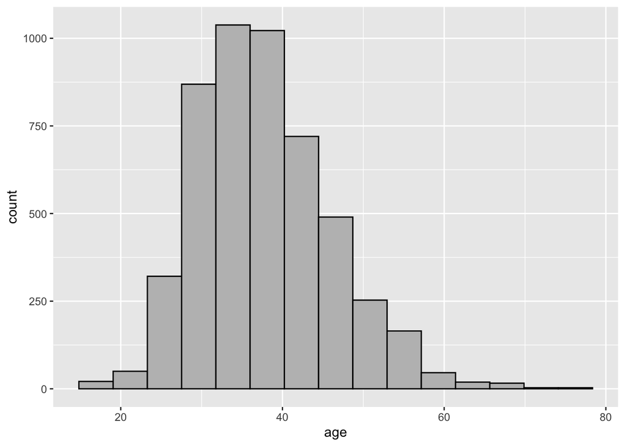

```r
# Distribution of Age
aids %>%
  ggplot(aes(x = age)) +
  geom_histogram(bins = 15, color = "black", fill = "gray")
```

```r
# Distribution of people in each treatment group
table(aids$treatment)
```

```
##
##    1    2    3    4
## 1239 1251 1254 1292
```

```r
round(prop.table(table(aids$treatment)), 2)
```

```
##
##    1    2    3    4
## 0.25 0.25 0.25 0.26
```

##Bivariate summaries

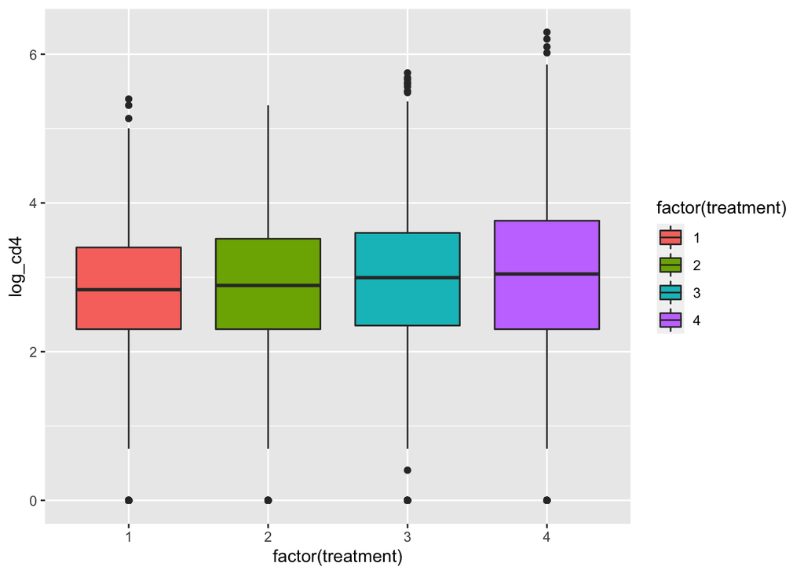

```r
#Boxplot based on treatment group
aids %>%
  ggplot(aes(x = factor(treatment), y = log_cd4,
             fill = factor(treatment))) +
  geom_boxplot()
```

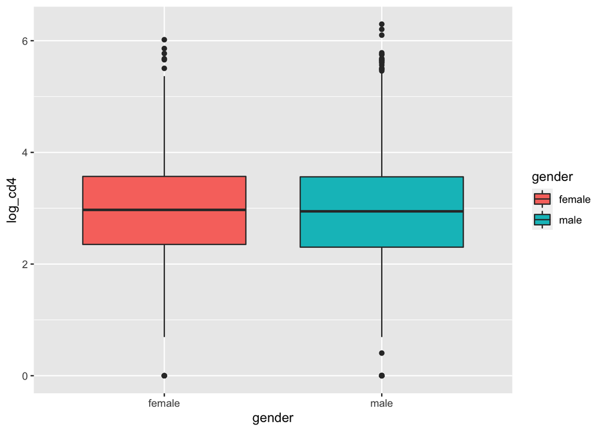

```r
#Boxplot based on gender
aids %>%
  ggplot(aes(x = gender, y = log_cd4, fill = gender)) +
  geom_boxplot()
```

##Overall trends of response —

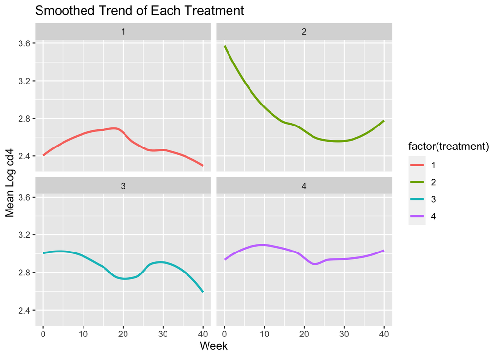

```r
# Mean log_cd4 per week of each treatment

aids %>%
 group_by(treatment, week) %>%
 summarize(mean_logcd4 = mean(log_cd4)) %>%
 ggplot(aes(x = week, y = mean_logcd4,  color =  factor(treatment))) +
 labs(title = "Smoothed Trend of Each Treatment",
      y = "Mean Log cd4", x = "Week") +
 geom_smooth(se = FALSE) +
  facet_wrap(~treatment)
```

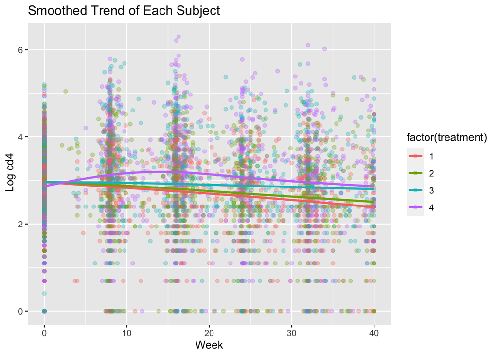

```r
# Trends pf each subject per week separated by treatment
aids %>%
 ggplot(aes(x = week, y = log_cd4, color = factor(treatment)))+
 geom_point(alpha = 0.3) +
 geom_smooth(se = FALSE) +
 labs(title = "Smoothed Trend of Each Subject",
      y = " Log cd4", x = "Week")
```

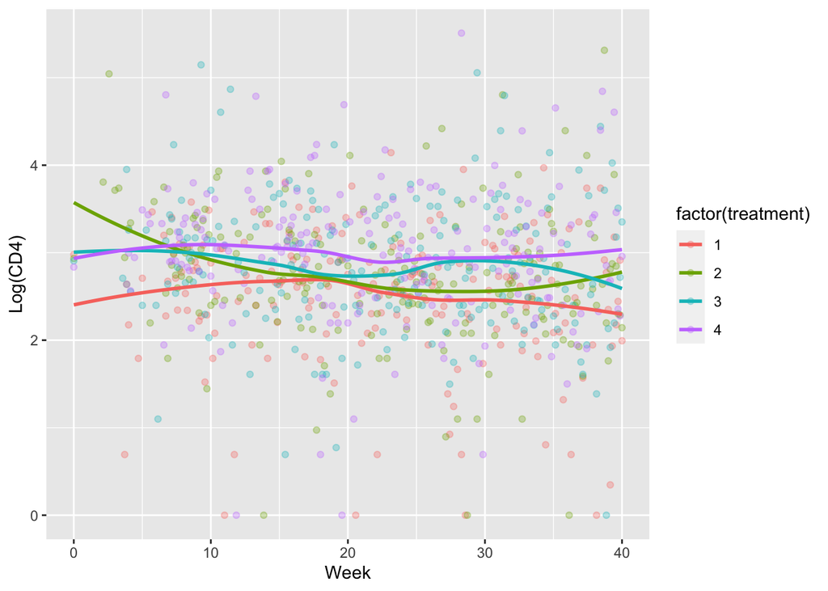

```r
aids %>%
  group_by(treatment, week) %>%
  summarize(mean_log_cd4 = mean(log_cd4, na.rm = TRUE)) %>%
  ggplot(aes(x = week, y = mean_log_cd4, color = factor(treatment))) +
  geom_point(alpha = 0.3) +
  geom_smooth(method = "loess", se = FALSE) +
  labs(x = "Week", y = "Log(CD4)")
```

In this plot, we can see that as the weeks increase, the mean values of log_cd4 for each treatment group stays relatively constant. There does seem to be a large scatter of points that might significantly deviate from the mean.

##Imbalances in the data —

```r
aids %>%
  group_by(id) %>%
  count() %>%
  summary()
```

```
##        id             n
##  Min.   :   1   Min.   :1.000
##  1st Qu.: 328   1st Qu.:3.000
##  Median : 656   Median :4.000
##  Mean   : 657   Mean   :3.847
##  3rd Qu.: 986   3rd Qu.:5.000
##  Max.   :1313   Max.   :9.000
```

We can see that the number of observations per id ranges from 1 to 9, with a median of 4 and a mean of around 3.8. It is safe to assume that the data is imbalanced, because each subject does not have a constant number of observations.

```r
aids %>%
  group_by(treatment) %>%
  distinct(id) %>%
  count()
```

```
## # A tibble: 4 x 2
## # Groups:   treatment [4]
##   treatment     n
##       <int> <int>
## 1         1   325
## 2         2   324
## 3         3   330
## 4         4   330
```

We can see that the amount of people in each treatment group is pretty balanced, with each treatment group having around 325 subjects.

#Mistimmed events?

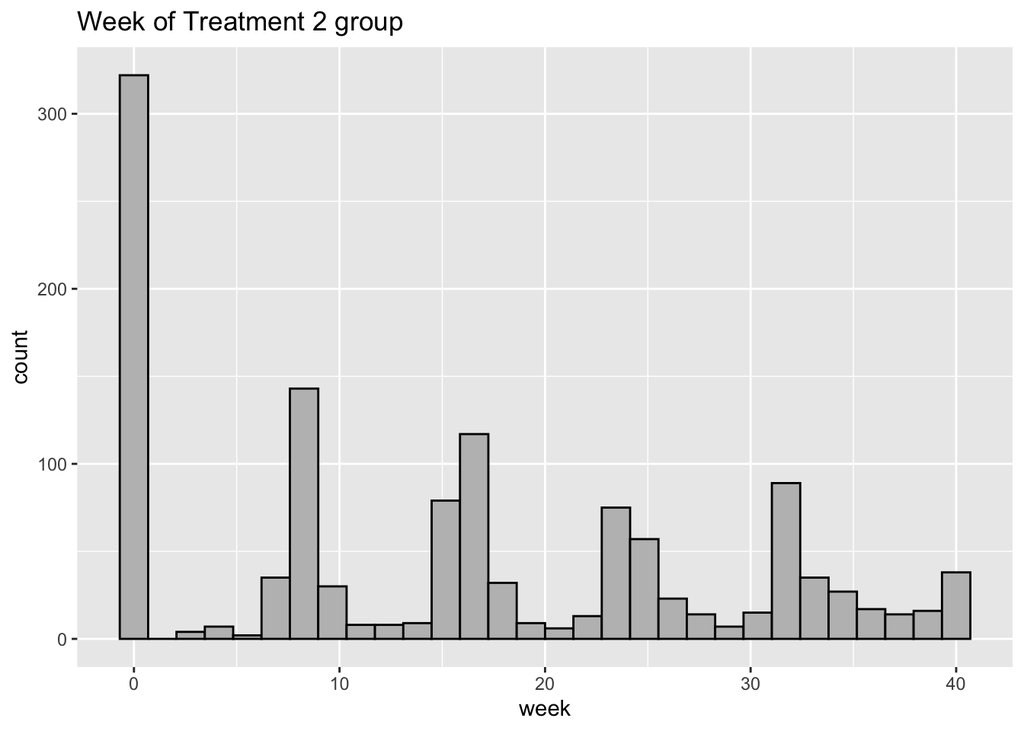

```r
aids %>%
  filter(treatment == 2) %>%
  ggplot(aes(x = week)) +
  geom_histogram(color = "black", fill = "gray") +
  labs(title = "Week of Treatment 2 group")
```

As we can see from this graph that all of those in treatment two have different timed occasions, if there were a set occasion then it would stack up similar to the base line or at week 0.

## Outliers —

We can see from the boxplots above there are quite a few outliers in the log_cd4 per treatment. To see the overall number of outliers we can create a boxplot of the log_cd4 and count the numbers outside of the interquartile range

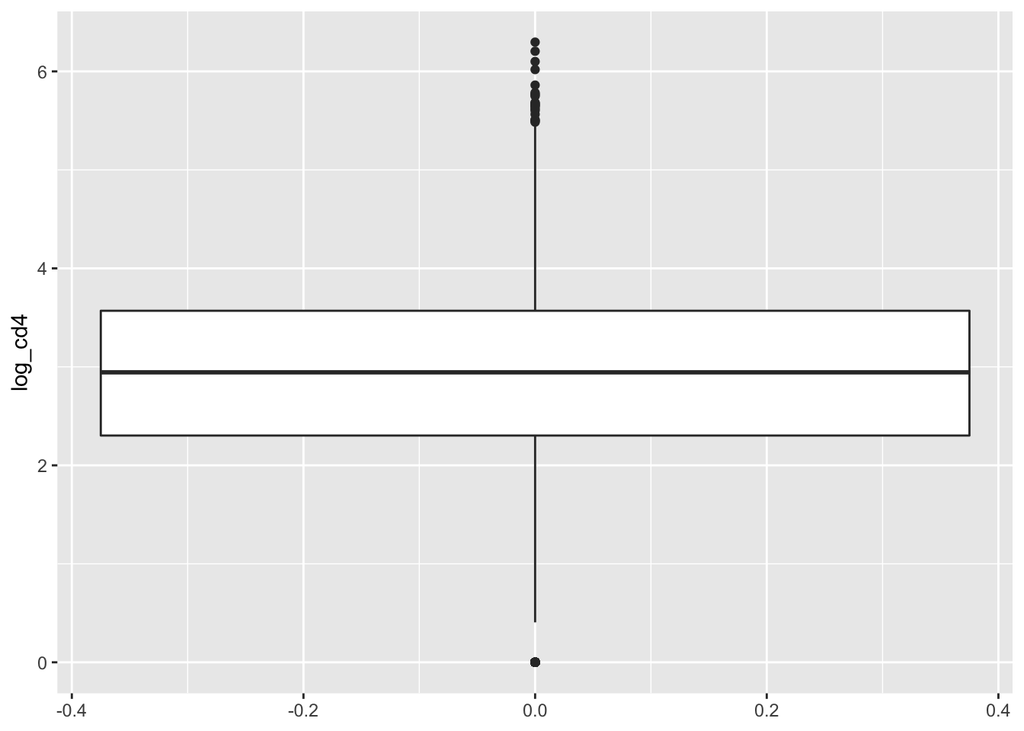

```r
aids %>%
  ggplot(aes(y = log_cd4)) +
  geom_boxplot()
```

These are the outliers and the total number of outliers are

```r
#outliers values
tibble(outliers = boxplot.stats(aids$log_cd4)$out )
```

```
## # A tibble: 199 x 1
##    outliers
##       <dbl>
##  1     0
##  2     0
##  3     0
##  4     0
##  5     0
##  6     5.68
##  7     5.62
##  8     5.78
##  9     5.65
## 10     0
## # … with 189 more rows
```

```r
#number of outliers
observerd = tibble(r = boxplot.stats(aids$log_cd4)$out) %>%
  nrow()

#expected number of outliers are
expected = nrow(aids) * .05
```

There is about 199 outliers and the expected is 251.8. We are below the number of expected number of outliers so the observed outliers are normal.

Let us check the distribution of the log_cd4 and assess its normality

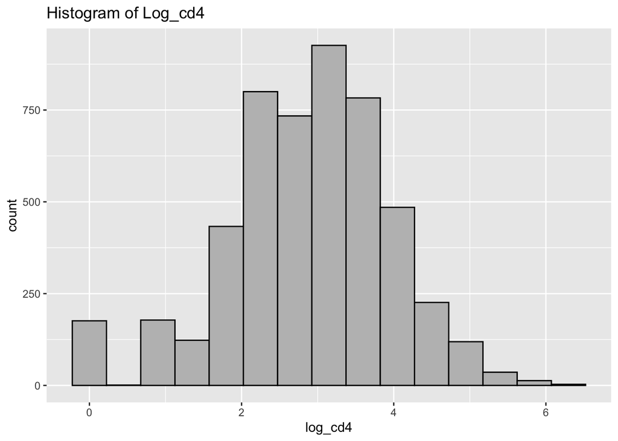

```r
aids %>%
  ggplot(aes(x = log_cd4)) +
   geom_histogram(bins = 15, color = "black", fill = "gray") +
   labs(title = "Histogram of Log_cd4")
```

The histogram its approximately normal, but we can get more information but standardizing the log_cd4

```r
# Standardized of log_cd4 with mean 0 and sd 1
log_cd4 = aids$log_cd4

scaled = scale(log_cd4)
colMeans(scaled)
```

```
## [1] -6.695151e-17
```

```r
apply(scaled, 2, sd)
```

```
## [1] 1
```

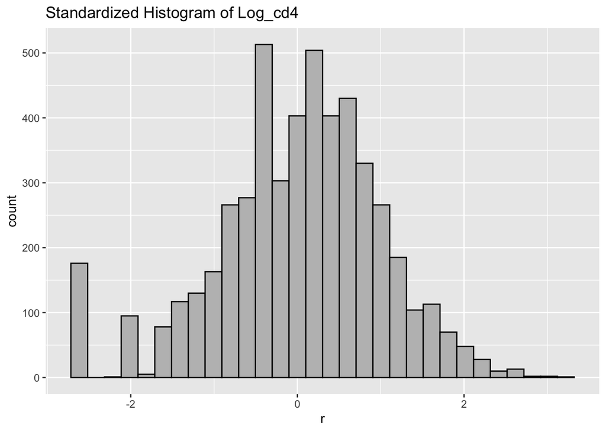

```r
tibble(r = scaled) %>%
  ggplot(aes(x = r)) +
  geom_histogram( color = "black", fill = "gray") +
  labs(title = "Standardized Histogram of Log_cd4")
```

We can see that there is quite a few number of instances after the -2. This indicates heavy tails as well as outliers

##modeling —–

```r
aids = aids %>%
  mutate(occasion = ceiling(week),
         gender = factor(gender, level = c("male", "female")),
         treatment = as.factor(treatment))


model1 = lme(log_cd4 ~ occasion + I(occasion^2) +
               treatment + treatment:occasion + age + gender, data = aids,
             random = ~ occasion + I(occasion^2)| id,
             method = "REML")

summary(model1)
```

```
## Linear mixed-effects model fit by REML
##  Data: aids
##        AIC      BIC   logLik
##   12003.36 12120.76 -5983.68
##
## Random effects:
##  Formula: ~occasion + I(occasion^2) | id
##  Structure: General positive-definite, Log-Cholesky parametrization
##               StdDev       Corr
## (Intercept)   0.7597452633 (Intr) occasn
## occasion      0.0428062078  0.324
## I(occasion^2) 0.0009857215 -0.387 -0.924
## Residual      0.5479490549
##
## Fixed effects: log_cd4 ~ occasion + I(occasion^2) + treatment + treatment:occasion +      age + gender
##                          Value  Std.Error   DF   t-value p-value
## (Intercept)          2.5725508 0.12584354 3722 20.442454  0.0000
## occasion            -0.0005280 0.00288826 3722 -0.182813  0.8550
## I(occasion^2)       -0.0004689 0.00006671 3722 -7.028160  0.0000
## treatment2          -0.0037095 0.07198368 1303 -0.051532  0.9589
## treatment3          -0.0250118 0.07172208 1303 -0.348733  0.7273
## treatment4          -0.0563613 0.07162232 1303 -0.786924  0.4315
## age                  0.0099982 0.00301069 1303  3.320898  0.0009
## genderfemale         0.0885844 0.07524912 1303  1.177215  0.2393
## occasion:treatment2  0.0025435 0.00243615 3722  1.044056  0.2965
## occasion:treatment3  0.0064171 0.00243646 3722  2.633766  0.0085
## occasion:treatment4  0.0153640 0.00240706 3722  6.382893  0.0000
##  Correlation:
##                     (Intr) occasn I(c^2) trtmn2 trtmn3 trtmn4 age    gndrfm
## occasion            -0.084
## I(occasion^2)        0.028 -0.801
## treatment2          -0.286  0.106 -0.002
## treatment3          -0.298  0.106 -0.001  0.503
## treatment4          -0.283  0.106 -0.001  0.503  0.505
## age                 -0.912  0.005 -0.003  0.001  0.013 -0.004
## genderfemale        -0.159  0.000  0.002 -0.023 -0.025 -0.018  0.105
## occasion:treatment2  0.072 -0.415 -0.013 -0.247 -0.125 -0.125 -0.002  0.000
## occasion:treatment3  0.074 -0.428  0.004 -0.124 -0.245 -0.125 -0.004  0.005
## occasion:treatment4  0.077 -0.422 -0.010 -0.126 -0.126 -0.248 -0.006  0.001
##                     occs:2 occs:3
## occasion
## I(occasion^2)
## treatment2
## treatment3
## treatment4
## age
## genderfemale
## occasion:treatment2
## occasion:treatment3  0.504
## occasion:treatment4  0.510  0.510
##
## Standardized Within-Group Residuals:
##         Min          Q1         Med          Q3         Max
## -4.46576901 -0.41658189  0.02939665  0.47411906  3.88574046
##
## Number of Observations: 5036
## Number of Groups: 1309
```

Because it is a randomized experiment we do not need the group effect of treatment and therefore treatmetn could be removed in the model

```r
model1 = lme(log_cd4 ~ occasion + I(occasion^2) +
             treatment:occasion + age + gender, data = aids,
             random = ~ occasion + I(occasion^2)| id,
             method = "REML")

summary(model1)
```

```
## Linear mixed-effects model fit by REML
##  Data: aids
##        AIC      BIC    logLik
##   11987.13 12084.97 -5978.565
##
## Random effects:
##  Formula: ~occasion + I(occasion^2) | id
##  Structure: General positive-definite, Log-Cholesky parametrization
##               StdDev       Corr
## (Intercept)   0.7592587842 (Intr) occasn
## occasion      0.0428586583  0.315
## I(occasion^2) 0.0009856581 -0.376 -0.925
## Residual      0.5479758078
##
## Fixed effects: log_cd4 ~ occasion + I(occasion^2) + treatment:occasion + age +      gender
##                          Value  Std.Error   DF   t-value p-value
## (Intercept)          2.5511461 0.11762587 3722 21.688649  0.0000
## occasion            -0.0003307 0.00286435 3722 -0.115469  0.9081
## I(occasion^2)       -0.0004694 0.00006671 3722 -7.036035  0.0000
## age                  0.0099991 0.00300763 1306  3.324567  0.0009
## genderfemale         0.0877436 0.07515589 1306  1.167488  0.2432
## occasion:treatment2  0.0025104 0.00236043 3722  1.063533  0.2876
## occasion:treatment3  0.0062042 0.00236184 3722  2.626841  0.0087
## occasion:treatment4  0.0148926 0.00233156 3722  6.387420  0.0000
##  Correlation:
##                     (Intr) occasn I(c^2) age    gndrfm occs:2 occs:3
## occasion            -0.042
## I(occasion^2)        0.030 -0.808
## age                 -0.973  0.004 -0.003
## genderfemale        -0.180  0.003  0.002  0.105
## occasion:treatment2  0.002 -0.404 -0.014 -0.001 -0.006
## occasion:treatment3  0.001 -0.418  0.004 -0.001 -0.002  0.503
## occasion:treatment4  0.007 -0.412 -0.010 -0.007 -0.003  0.510  0.510
##
## Standardized Within-Group Residuals:
##         Min          Q1         Med          Q3         Max
## -4.46380841 -0.41634607  0.02902356  0.47566900  3.88302174
##
## Number of Observations: 5036
## Number of Groups: 1309
```

```r
model_no_gender = lme(log_cd4 ~ occasion + I(occasion^2) +
             treatment:occasion + treatment:I(occasion^2) +
               age, data = aids,
             random = ~ occasion + I(occasion^2)| id,
             method = "ML")

model = lme(log_cd4 ~ occasion + I(occasion^2) +
             treatment:occasion + treatment:I(occasion^2) + age + gender, data = aids,
             random = ~ occasion + I(occasion^2)| id,
             method = "ML")

anova(model_no_gender, model)
```

```
##                 Model df      AIC      BIC    logLik   Test  L.Ratio p-value
## model_no_gender     1 17 11888.81 11999.73 -5927.406
## model               2 18 11889.47 12006.91 -5926.734 1 vs 2 1.343241  0.2465
```

```r
model_interactions = lme(log_cd4 ~  occasion + I(occasion^2) +
             treatment:occasion + treatment:I(occasion^2) +
               age, data = aids,
             random = ~ occasion + I(occasion^2)| id,
             method = "ML")

model_without_interaction = lme(log_cd4 ~  occasion + I(occasion^2) +
             age, data = aids,
             random = ~ occasion + I(occasion^2)| id,
             method = "ML")

anova(model_interactions, model_without_interaction)
```

```
##                           Model df      AIC      BIC    logLik   Test  L.Ratio
## model_interactions            1 17 11888.81 11999.73 -5927.406
## model_without_interaction     2 11 11946.51 12018.27 -5962.253 1 vs 2 69.69495
##                           p-value
## model_interactions
## model_without_interaction  <.0001
```

$H_0:$ the reduced model without interactions terms is better

Reject the null (p-value <.0001 ), and conclude that the model with interaction term is better compared to the model without without interaction terms

```r
model_no_gender = lme(log_cd4 ~ occasion + I(occasion^2) +
             treatment:occasion + treatment:I(occasion^2)
               +  age, data = aids,
             random = ~ occasion + I(occasion^2)| id,
             method = "REML")
summary(model_no_gender)
```

```
## Linear mixed-effects model fit by REML
##  Data: aids
##        AIC      BIC    logLik
##   12012.15 12123.03 -5989.074
##
## Random effects:
##  Formula: ~occasion + I(occasion^2) | id
##  Structure: General positive-definite, Log-Cholesky parametrization
##               StdDev       Corr
## (Intercept)   0.7599938521 (Intr) occasn
## occasion      0.0419502978  0.324
## I(occasion^2) 0.0009560662 -0.388 -0.921
## Residual      0.5471601520
##
## Fixed effects: log_cd4 ~ occasion + I(occasion^2) + treatment:occasion + treatment:I(occasion^2) +      age
##                               Value  Std.Error   DF   t-value p-value
## (Intercept)               2.5752869 0.11577884 3719 22.243157  0.0000
## occasion                 -0.0121774 0.00490731 3719 -2.481477  0.0131
## I(occasion^2)            -0.0001246 0.00013405 3719 -0.929607  0.3526
## age                       0.0096541 0.00299309 1307  3.225454  0.0013
## occasion:treatment2       0.0073306 0.00687138 3719  1.066826  0.2861
## occasion:treatment3       0.0186714 0.00686433 3719  2.720053  0.0066
## occasion:treatment4       0.0438518 0.00679921 3719  6.449549  0.0000
## I(occasion^2):treatment2 -0.0001429 0.00018701 3719 -0.764175  0.4448
## I(occasion^2):treatment3 -0.0003638 0.00018841 3719 -1.931005  0.0536
## I(occasion^2):treatment4 -0.0008388 0.00018542 3719 -4.523868  0.0000
##  Correlation:
##                          (Intr) occasn I(c^2) age    occs:2 occs:3 occs:4
## occasion                 -0.026
## I(occasion^2)             0.016 -0.939
## age                      -0.975  0.003 -0.002
## occasion:treatment2       0.002 -0.707  0.666 -0.001
## occasion:treatment3       0.002 -0.707  0.667 -0.002  0.505
## occasion:treatment4       0.002 -0.714  0.673 -0.001  0.510  0.510
## I(occasion^2):treatment2 -0.002  0.669 -0.714  0.001 -0.939 -0.478 -0.482
## I(occasion^2):treatment3 -0.002  0.663 -0.709  0.002 -0.474 -0.939 -0.479
## I(occasion^2):treatment4  0.000  0.674 -0.720 -0.001 -0.481 -0.482 -0.939
##                          I(^2):2 I(^2):3
## occasion
## I(occasion^2)
## age
## occasion:treatment2
## occasion:treatment3
## occasion:treatment4
## I(occasion^2):treatment2
## I(occasion^2):treatment3  0.508
## I(occasion^2):treatment4  0.516   0.512
##
## Standardized Within-Group Residuals:
##         Min          Q1         Med          Q3         Max
## -4.48485816 -0.41732683  0.02411476  0.46989002  3.88629654
##
## Number of Observations: 5036
## Number of Groups: 1309
```

```r
model_linear = lme(log_cd4 ~ occasion  +
             treatment:occasion +  age, data = aids,
             random = ~ occasion | id,
             method = "ML")

model_quadratic = lme(log_cd4 ~ occasion + I(occasion^2) +
             treatment:occasion + treatment:I(occasion^2)
               +  age, data = aids,
             random = ~ occasion + I(occasion^2)| id,
             method = "ML")

anova(model_linear, model_quadratic)
```

```
##                 Model df      AIC      BIC    logLik   Test  L.Ratio p-value
## model_linear        1 10 12049.15 12114.40 -6014.577
## model_quadratic     2 17 11888.81 11999.73 -5927.406 1 vs 2 174.3419  <.0001
```

$H_0:$ the reduced model without quadratic terms are better

Reject the null (p-value <.0001 ), and conclude that the model with quadratic terms better compared linear model

We will first compare a linear model with a linear spline model.  
Linear Spline Model: $E(Y_{ij}|b_i) = \beta_1 + \beta_2occasion_{ij} + \beta_3age_{ij} + \beta_4(occasion_{ij})_+ + \beta_5occasion_{ij}treatment2 + \beta_6occasion_{ij}treatment3 + \beta_7occasion_{ij}treatment4 + b_{1i} + b_{2i}occasion_{ij} + b_{3i}(occasion_{ij})_+$

```r
aids <- aids %>%
    mutate(knot_term = if_else(occasion > 20, occasion, 0)) %>%
    relocate(knot_term, .after = occasion)

ctrl <- lmeControl(opt = 'optim')
model_spline = lme(log_cd4 ~ occasion +
             treatment:occasion + age + knot_term, data = aids,
             random = ~ occasion + knot_term| id,
             method = "ML",
             control = ctrl)
summary(model_spline)
```

```
## Linear mixed-effects model fit by maximum likelihood
##  Data: aids
##        AIC      BIC    logLik
##   11941.88 12033.22 -5956.939
##
## Random effects:
##  Formula: ~occasion + knot_term | id
##  Structure: General positive-definite, Log-Cholesky parametrization
##             StdDev     Corr
## (Intercept) 0.76050923 (Intr) occasn
## occasion    0.02619406  0.384
## knot_term   0.01358634 -0.594 -0.823
## Residual    0.56327923
##
## Fixed effects: log_cd4 ~ occasion + treatment:occasion + age + knot_term
##                          Value  Std.Error   DF   t-value p-value
## (Intercept)          2.5773059 0.11615993 3722 22.187563  0.0000
## occasion            -0.0068531 0.00219308 3722 -3.124886  0.0018
## age                  0.0098307 0.00300362 1307  3.272971  0.0011
## knot_term           -0.0090536 0.00130381 3722 -6.943988  0.0000
## occasion:treatment2  0.0021962 0.00235061 3722  0.934292  0.3502
## occasion:treatment3  0.0062519 0.00234758 3722  2.663109  0.0078
## occasion:treatment4  0.0149463 0.00232161 3722  6.437894  0.0000
##  Correlation:
##                     (Intr) occasn age    knt_tr occs:2 occs:3
## occasion            -0.040
## age                 -0.976  0.005
## knot_term            0.024 -0.643 -0.002
## occasion:treatment2  0.003 -0.535 -0.003 -0.006
## occasion:treatment3  0.003 -0.539 -0.003 -0.001  0.503
## occasion:treatment4  0.007 -0.544 -0.007 -0.003  0.509  0.510
##
## Standardized Within-Group Residuals:
##         Min          Q1         Med          Q3         Max
## -4.28379387 -0.43149011  0.02881998  0.48414071  3.78689270
##
## Number of Observations: 5036
## Number of Groups: 1309
```

```r
anova(model_linear, model_spline)
```

```
##              Model df      AIC      BIC    logLik   Test  L.Ratio p-value
## model_linear     1 10 12049.15 12114.40 -6014.577
## model_spline     2 14 11941.88 12033.22 -5956.939 1 vs 2 115.2758  <.0001
```

### Quadratic Before Knot Term, Linear After Knot Term Spline

Spline Model: $E(Y_{ij}|b_i) = \beta_1 + \beta_2occasion_{ij} + \beta_3age_{ij} + \beta_4(occasion^2_{ij})_+ + \beta_5occasion_{ij}treatment2 + \beta_6occasion_{ij}treatment3 + \beta_7occasion_{ij}treatment4 + b_{1i} + b_{2i}occasion_{ij} + b_{3i}(occasion^2_{ij})_+$

```r
aids <- aids %>%
    mutate(knot_term1 = if_else(occasion > 20, occasion^2, 0)) %>%
    relocate(knot_term1, .after = occasion)

ctrl <- lmeControl(opt = 'optim')
model_spline1 = lme(log_cd4 ~ occasion +
             treatment:occasion + age + knot_term1, data = aids,
             random = ~ occasion + knot_term1| id,
             method = "ML",
             control = ctrl)
summary(model_spline1)
```

```
## Linear mixed-effects model fit by maximum likelihood
##  Data: aids
##        AIC      BIC    logLik
##   11928.38 12019.72 -5950.191
##
## Random effects:
##  Formula: ~occasion + knot_term1 | id
##  Structure: General positive-definite, Log-Cholesky parametrization
##             StdDev       Corr
## (Intercept) 0.7667446827 (Intr) occasn
## occasion    0.0304906912  0.251
## knot_term1  0.0006234473 -0.302 -0.820
## Residual    0.5446817154
##
## Fixed effects: log_cd4 ~ occasion + treatment:occasion + age + knot_term1
##                          Value  Std.Error   DF   t-value p-value
## (Intercept)          2.5770688 0.11606743 3722 22.203204  0.0000
## occasion            -0.0071801 0.00221200 3722 -3.245971  0.0012
## age                  0.0097312 0.00300089 1307  3.242781  0.0012
## knot_term1          -0.0002729 0.00004061 3722 -6.719113  0.0000
## occasion:treatment2  0.0024569 0.00239745 3722  1.024809  0.3055
## occasion:treatment3  0.0064907 0.00239500 3722  2.710092  0.0068
## occasion:treatment4  0.0153555 0.00236788 3722  6.484933  0.0000
##  Correlation:
##                     (Intr) occasn age    knt_t1 occs:2 occs:3
## occasion            -0.043
## age                 -0.976  0.005
## knot_term1           0.031 -0.633 -0.003
## occasion:treatment2  0.002 -0.539 -0.002 -0.010
## occasion:treatment3  0.002 -0.547 -0.002  0.002  0.503
## occasion:treatment4  0.006 -0.547 -0.006 -0.008  0.509  0.510
##
## Standardized Within-Group Residuals:
##         Min          Q1         Med          Q3         Max
## -4.38569488 -0.41817029  0.03036286  0.46772689  3.87655343
##
## Number of Observations: 5036
## Number of Groups: 1309
```

```r
anova(model_spline, model_spline1)
```

```
##               Model df      AIC      BIC    logLik
## model_spline      1 14 11941.88 12033.22 -5956.939
## model_spline1     2 14 11928.38 12019.72 -5950.191
```

```r
anova(model_linear, model_spline1)
```

```
##               Model df      AIC      BIC    logLik   Test  L.Ratio p-value
## model_linear      1 10 12049.15 12114.40 -6014.577
## model_spline1     2 14 11928.38 12019.72 -5950.191 1 vs 2 128.7711  <.0001
```

```r
anova(model_quadratic, model_spline1)
```

```
##                 Model df      AIC      BIC    logLik   Test  L.Ratio p-value
## model_quadratic     1 17 11888.81 11999.73 -5927.406
## model_spline1       2 14 11928.38 12019.72 -5950.191 1 vs 2 45.57089  <.0001
```

When comparing a quadratic model to the model with a quadratic function before the knot term and linear function after the knot term, we can see that the AIC of the quadratic model is lower than the spline model. We can conclude that the quadratic model fits the data better than the spline model.

### Quadratic Spline Model

Quadratic Spline Model: $E(Y_{ij}|b_i) = \beta_1 + \beta_2occasion_{ij} + \beta_2occasion^2_{ij} + \beta_4age_{ij} + \beta_5(occasion^2_{ij})_+ + \beta_6occasion_{ij}treatment2 + \beta_7occasion_{ij}treatment3 + \beta_8occasion_{ij}treatment4 + b_{1i} + b_{2i}occasion_{ij} + b_{3i}(occasion^2_{ij})_+$

```r
ctrl <- lmeControl(opt = 'optim')
model_quad_splines = lme(log_cd4 ~ occasion + I(occasion^2) +
             treatment:occasion + age + knot_term1, data = aids,
             random = ~ occasion + I(occasion^2) + knot_term1| id,
             method = "ML",
             control = ctrl)
summary(model_quad_splines)
```

```
## Linear mixed-effects model fit by maximum likelihood
##  Data: aids
##        AIC      BIC    logLik
##   11921.09 12045.05 -5941.544
##
## Random effects:
##  Formula: ~occasion + I(occasion^2) + knot_term1 | id
##  Structure: General positive-definite, Log-Cholesky parametrization
##               StdDev       Corr
## (Intercept)   0.7651254826 (Intr) occasn I(c^2)
## occasion      0.0415629285  0.301
## I(occasion^2) 0.0010754860 -0.326 -0.770
## knot_term1    0.0004822352 -0.012 -0.161 -0.353
## Residual      0.5368714776
##
## Fixed effects: log_cd4 ~ occasion + I(occasion^2) + treatment:occasion + age +      knot_term1
##                          Value  Std.Error   DF   t-value p-value
## (Intercept)          2.5752520 0.11573069 3721 22.252111  0.0000
## occasion            -0.0010949 0.00342972 3721 -0.319227  0.7496
## I(occasion^2)       -0.0004096 0.00017103 3721 -2.394676  0.0167
## age                  0.0096239 0.00299185 1307  3.216695  0.0013
## knot_term1          -0.0000438 0.00010154 3721 -0.431598  0.6661
## occasion:treatment2  0.0025108 0.00242857 3721  1.033868  0.3013
## occasion:treatment3  0.0063646 0.00242577 3721  2.623729  0.0087
## occasion:treatment4  0.0153925 0.00239824 3721  6.418256  0.0000
##  Correlation:
##                     (Intr) occasn I(c^2) age    knt_t1 occs:2 occs:3
## occasion            -0.036
## I(occasion^2)        0.013 -0.763
## age                 -0.975  0.004 -0.003
## knot_term1          -0.001  0.541 -0.918  0.002
## occasion:treatment2  0.001 -0.346 -0.007 -0.001  0.003
## occasion:treatment3  0.001 -0.361  0.005 -0.001 -0.004  0.503
## occasion:treatment4  0.006 -0.353 -0.006 -0.006  0.003  0.509  0.509
##
## Standardized Within-Group Residuals:
##         Min          Q1         Med          Q3         Max
## -4.53347199 -0.41107893  0.02896096  0.46504126  3.90900639
##
## Number of Observations: 5036
## Number of Groups: 1309
```

```r
anova(model_quadratic, model_quad_splines)
```

```
##                    Model df      AIC      BIC    logLik   Test  L.Ratio p-value
## model_quadratic        1 17 11888.81 11999.73 -5927.406
## model_quad_splines     2 19 11921.09 12045.05 -5941.544 1 vs 2 28.27542  <.0001
```

### We can conclude that it is better to use the quadratic model than both a spline model and a linear model.

The equation that we have concluded is: has the lowest AIC

Y = B1 + B2 * occasion + B3 * occasion^2 + B4 * age + B5 * occasion:treatment2 + B6 * occasion:treatment3 + B7 * occasion:treatment4 + B8 * occasion^2:treatment2 + B9 * occasion^2:treatment3 + B10 * occasion^2:treatment4

Note: We did not remove the interaction terms or occasion that are not significant since the other interaction terms or occasion was significant. Occasion is significant but occasion^2 is not, and some interaction terms of occasion^2 is siginificant